# BIOS-611 Blog Post 1

Arryn Panagos

September 24, 2018

```r
#load libraries used
library(tidyverse)
library(knitr)
library(matrixStats)
```

## Data Set 1: How religion may impact fertility, a historical perspective.

The first data set,`swiss` is Swiss socioeconomic data from Princeton University’s Office of Population Research. It was compiled by Francine Van de Walle in 1976. The data was gathered from the different French speaking districts in Switzerland, all from 1888.

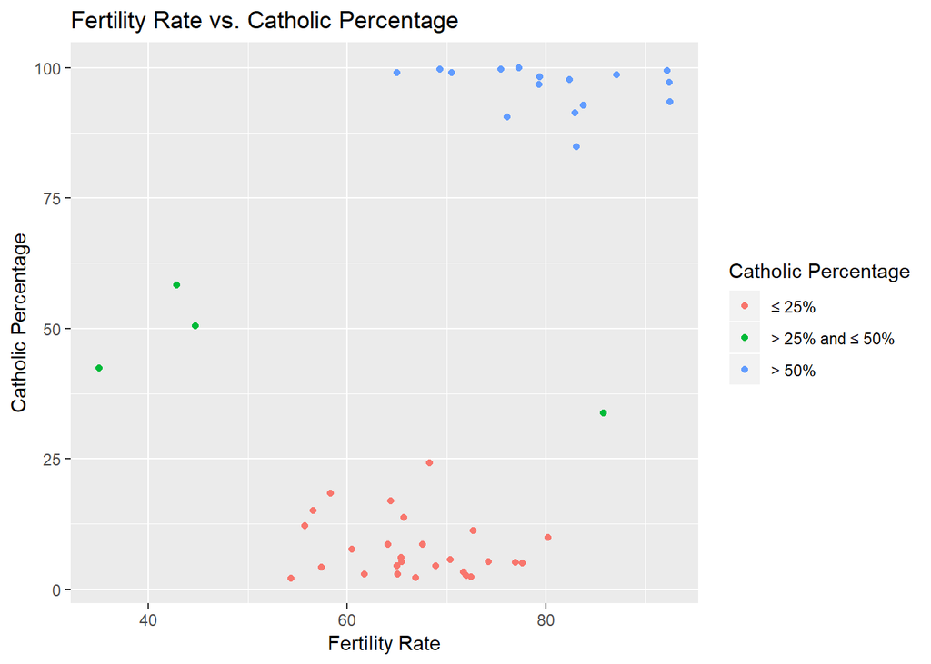

```r
#load data
data(swiss)
#add column which segments by percent of catholicism
swiss_group<-mutate(swiss,Percentage_Catholic=as.factor(ifelse(Catholic<=25,"\u2264 25%",ifelse(Catholic>25 & Catholic<=75,"> 25% and \u2264 50%","> 50%"))))
#create scatter plot which is colored by the previously created segment
ggplot(data=swiss_group,aes(Fertility,Catholic,color=Percentage_Catholic))+geom_point()+ggtitle("Fertility Rate vs. Catholic Percentage")+ylab("Catholic Percentage")+xlab("Fertility Rate")+ labs(color='Catholic Percentage')
```

We see what appears to be at least two separate clusters in our scatter plot. One which has very high fertility and very high Catholicism (in blue); the other has medium fertility and low Catholicism (in red). There is also a possible third group (in green), but there are too few data points (only 4) to be certain. This shows an interesting phenomena taking place in 1888 Switzerland and probably across much of Europe. We see that there is a significant gap in Catholicism, but what is the difference in distributions of Fertility?

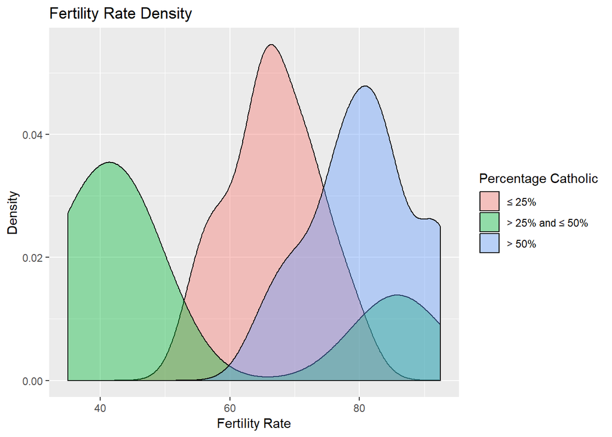

```r
#create density plot grouped by the previously made percent catholic bins
ggplot(data=swiss_group,aes(Fertility,fill=Percentage_Catholic))+geom_density(alpha=.4)+ggtitle("Fertility Rate Density")+ylab("Density")+xlab("Fertility Rate")+scale_fill_discrete(name="Percentage Catholic")
```

Above we have a density plot with the Fertility rate on the x-axis with its distribution segmented by the three groups we identified on the previous graph by color. The distributions for the red group and the blue group are indeed different. The mean and standard deviation of the red group are 66.65 and 6.86 respectively. The mean and standard deviation of the blue group are 80.55 and 8.23.

This shows that there is evidence that Catholicism and fertility rates are correlated. It would be useful to follow up by looking into how other factors could impact this correlation. Geographic coordinates for each district might show that both fertility rates and Catholicism might be connected with the specific location of the district. Also given the year 1888, it would be interesting to look at how industrialization impacted both Catholicism and fertility rates.

## Data Set Two: Taking a closer look at bias, deception of numbers.

The second data set, `UCBAdmissions` is the aggregation of graduate admissions data to UC Berkeley’s six largest department for the year 1973. The data was originally compiled by P. J. Bickel, E. A. Hammel and J. W. O’Connell in their 1975 paper.

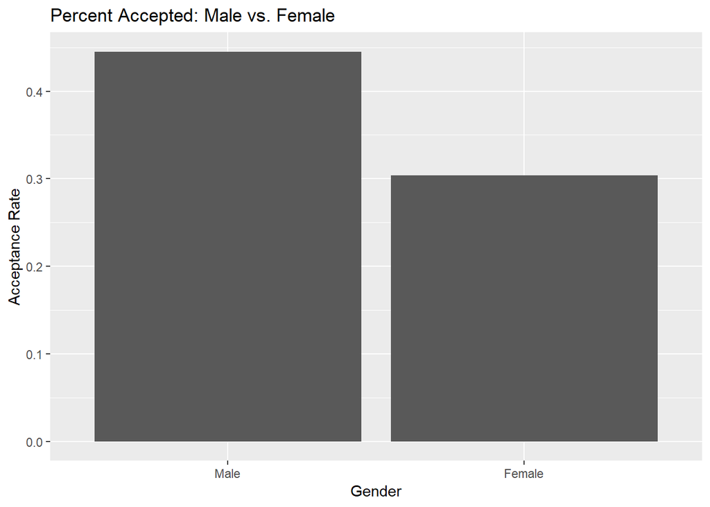

```r
#load data
data(UCBAdmissions)
#change to a data frame
UCBAdmissions<-data.frame(UCBAdmissions)
#find the percent accepted by gender
raw_acceptance<-group_by(UCBAdmissions,Gender) %>%
  summarize(percent_accepted=sum(ifelse(Admit=="Admitted",Freq,0))/sum(Freq))
#create bar plot showing percent accepted between men and women
ggplot(data=raw_acceptance,aes(Gender,percent_accepted))+geom_bar( position = "dodge", stat="identity")+ylab("Acceptance Rate")+ggtitle("Percent Accepted: Male vs. Female")
```

The chart above shows the acceptance rate between men and women. We see that on average women are accepted 30.35% of the time and men are accepted 44.52% of the time. Given this graph, it definitely looks likely that those who admitting the students are preferring men much more than women; or are they? What if we instead looked at the admissions rate for each department separately?

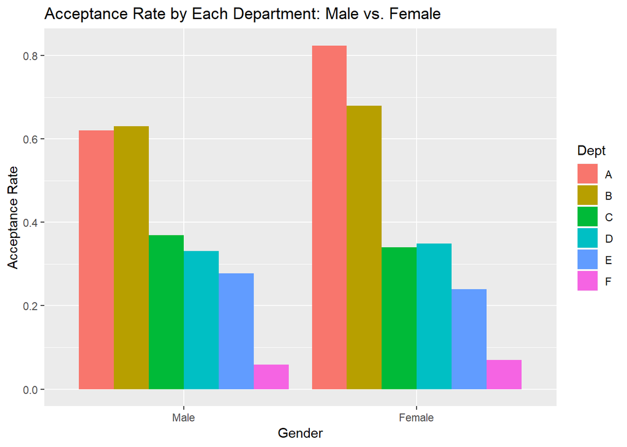

```r
#percent accepted by gender and department
UCBAdmissions_dept_acceptance<-UCBAdmissions %>%
  group_by(Gender,Dept) %>%
  summarize(percent_accepted=sum(ifelse(Admit=="Admitted",Freq,0))/sum(Freq))

#create bar plot showing percent accepted grouped by gender and department
ggplot(data=UCBAdmissions_dept_acceptance,aes(Gender,percent_accepted))+geom_bar(aes(fill=Dept), position = "dodge", stat="identity")+ylab("Acceptance Rate")+ggtitle("Acceptance Rate by Each Department: Male vs. Female")
```

Above we see a graph looking at the acceptance rate for each department separately still grouped by Male and Female. But what is this? We do not see much evidence from this graph that men are being accepted more than women. Only 2 out of 6 departments have the average acceptance rate higher for men than for women. Why is this the case? Could it have to do with the number of raw applicants?

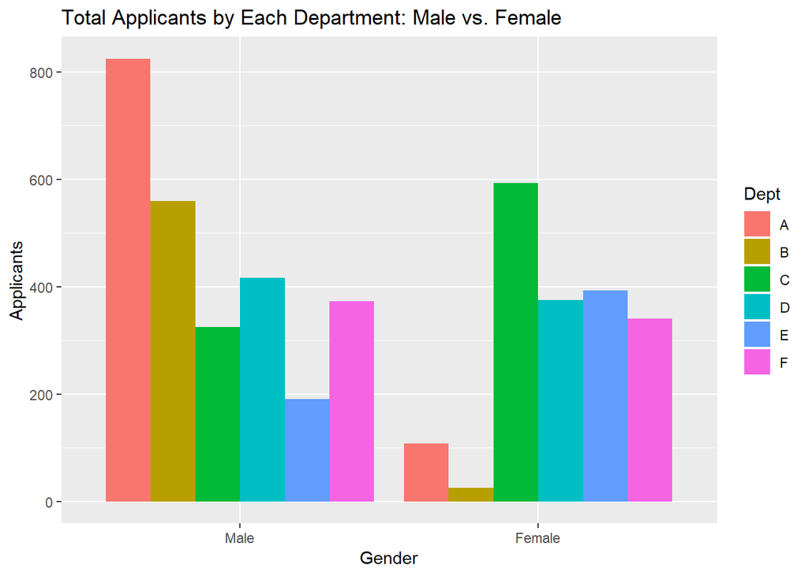

```r
#sum total number of applicants by each department
UCBAdmissions %>%
  group_by(Gender, Dept) %>%
  summarize(Applicants=sum(Freq)) %>%
#graph total number of applicants by each department
ggplot(aes(Gender,Applicants))+geom_bar(aes(fill=Dept), position = "dodge", stat="identity")+ylab("Applicants")+ggtitle("Total Applicants by Each Department: Male vs. Female")
```

Above shows the total applicants for each department grouped by gender. Clearly there are more male applications, but what are most male applicants applying to? The departments A and B, whereas the females are barely applying to those at all. Which departments have the highest acceptance rate? Departments A and B. This helps explain why the overall acceptance rate is more preferable to males. Indeed, let us see what the overall acceptance rate is when normalizing for each department (i.e. treat each application count per department as the same).

```r
#find average acceptance rate between the departments and genders
UCBAdmissions_acceptance_normdep<-UCBAdmissions_dept_acceptance %>%
  group_by(Gender) %>%
  summarize(percent_accepted=mean(percent_accepted)) %>%
  rename("Acceptance Rate"=percent_accepted)
#print out table
kable(UCBAdmissions_acceptance_normdep)
```

| Gender | Acceptance Rate |
| --- | --- |
| Male | 0.3812662 |
| Female | 0.4172692 |

This confirms what we suspected; when taking each department into account we see that women have a slightly higher acceptance rate than men. This phenomena (also called Simpson’s Paradox) demonstrates the caution one must have when doing statistics (and data analysis in general).

## Data Set Three: Rich women and rich children, reality aboard the Titanic.

The third data, `Titanic` set consists of passenger information who were aboard the titanic before it sunk. The variables are Class, Sex, Age, and Survived (True or False) for each passenger. The original data was collected by the British Board of Trade and cited in a re-print from 1990, Report on the Loss of the ‘Titanic’ (S.S.).

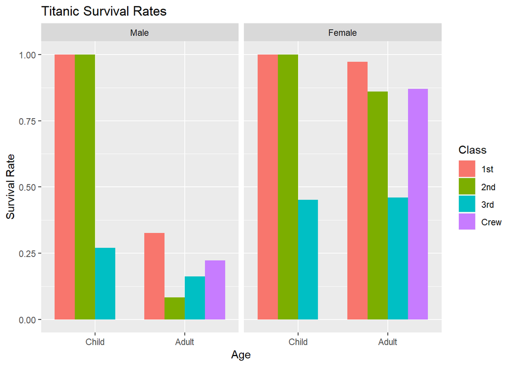

```r
#load Titanic data
data(Titanic)
#convert to data frame
Titanic<-data.frame(Titanic)
#find percentage survived per class/sex/age
Titanic_rate<-Titanic %>%
  group_by(Class,Sex,Age) %>%
  summarize(percent_survived=sum(ifelse(Survived=="Yes",Freq,0))/sum(Freq))
#graph bar plot of survival rate for each sex and age colored by class.
ggplot(Titanic_rate,aes(Age,percent_survived,fill=Class))+geom_bar(position="dodge",stat="identity")+ylab("Survival Rate")+facet_grid(~Sex)+ggtitle("Titanic Survival Rates")
```

```r
#find survial rate between all males and females
Titanic_rate_sex<-Titanic %>%
  group_by(Sex) %>%
  summarize(percent_survived=sum(ifelse(Survived=="Yes",Freq,0))/sum(Freq)) %>%
  rename("Survival Rate"=percent_survived)
#print table
kable(Titanic_rate_sex)
```

| Sex | Survival Rate |
| --- | --- |
| Male | 0.2120162 |
| Female | 0.7319149 |

```r
#find survival rate between classes
Titanic_rate_class<-Titanic %>%
  group_by(Class) %>%
  summarize(percent_survived=sum(ifelse(Survived=="Yes",Freq,0))/sum(Freq)) %>%
  rename("Survival Rate"=percent_survived)
#print table
kable(Titanic_rate_class)
```

| Class | Survival Rate |
| --- | --- |
| 1st | 0.6246154 |
| 2nd | 0.4140351 |
| 3rd | 0.2521246 |
| Crew | 0.2395480 |

The two tables above further shows the difference of survival between the sexes and the classes. This, along with the bar chart, shows how different your chances of survival was if you were a female or child with wealth enough to be at least 2nd class.

## Data Set Four: Orange juice may be than ascorbic acid for teeth growth.

The fourth data set, `ToothGrowth` consists of 60 guinea pigs given doses of vitamin C via orange juice or ascorbic acid (a basic form of vitamin C) to see how the doses impact the length of their odontoblasts which are the cells responsible for tooth growth. The source of the data came from the work of E.W. Crampton in his 1947 paper, The growth of the odontoblast of the incisor teeth as a criterion of vitamin C intake of the guinea pig.

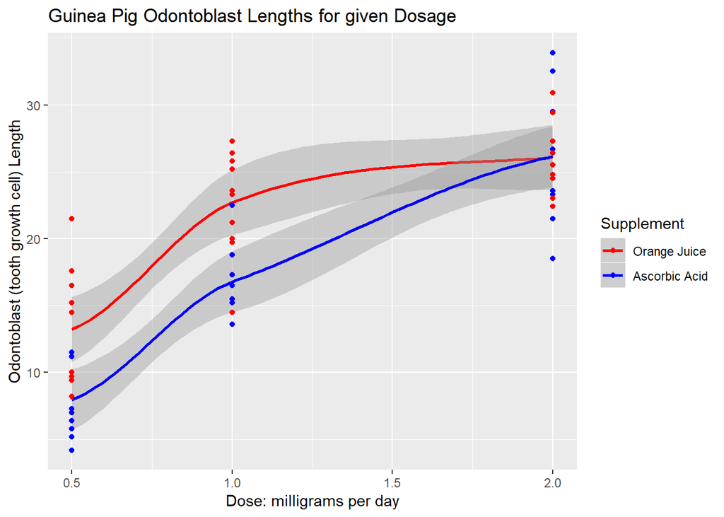

```r
#load ToothGrowth data
data(ToothGrowth)
#graph scatter plot and smoothed lines finding between the two supplements
ggplot(data=ToothGrowth,aes((dose),len,colour=supp))+geom_smooth()+geom_point()+xlab("Dose: milligrams per day")+ylab("Odontoblast (tooth growth cell) Length")+labs(color="Supplement")+scale_color_manual(labels=c("Orange Juice","Ascorbic Acid"),values=c("red","blue"))+ggtitle("Guinea Pig Odontoblast Lengths for given Dosage")
```

Above we have each data point plotted where dose is on the x-axis and the length of the odontoblasts (tooth growth cells) is on the y-axis. A smoothing function has been applied, the smoothing method used was loess, with a 95% confidence interval representing the shaded region around each smoothed line. We see that overall the orange juice tends to out perform ascorbic acid for every dose except for when the the dose is 2 mil/day.

```r
#find mean and stdev for both orange juice and ascorbic acid
ToothGrowth_mean<-ToothGrowth %>%
  group_by(Supplement=supp) %>%
  summarise(Mean=mean(len),"Standard Deviation"=sd(len))
#print table
kable(ToothGrowth_mean)
```

| Supplement | Mean | Standard Deviation |
| --- | --- | --- |
| OJ | 20.66333 | 6.605561 |
| VC | 16.96333 | 8.266029 |

Above is a table showing the mean and table deviation of the `len` (odontoblast length) grouped by `OJ` (Orange Juice) and `VC` (Ascorbic Acid). The mean for Orange Juice is greater than ascorbic acid. Given that orange juice has a higher odontoblast length for doses 0.5 and 1.0, this indicates there may be something in orange juice which is helping the odontoblast length besides the vitamin C. This also shows that consuming orange juice may be better for tooth growth than taking the equivalent amount of vitamin C through supplements. It is difficult to conclude if the two supplements would have the same affect on the odontoblast length for doses greater than 2. A further study could look into this and give pigs a higher dosage.